# COURSERA : Reproducible research - Peer Assessment 1

> Loading and preprocess the data

Ensure the required files are in source directory read the source files

```r
    activity <- read.csv("activity.csv",stringsAsFactors = FALSE)
```

Summary of read source file - “activity.csv”

```r
str(activity)
```

```
## 'data.frame':    17568 obs. of  3 variables:
##  $ steps   : int  NA NA NA NA NA NA NA NA NA NA ...
##  $ date    : chr  "2012-10-01" "2012-10-01" "2012-10-01" "2012-10-01" ...
##  $ interval: int  0 5 10 15 20 25 30 35 40 45 ...
```

```r
head(activity)
```

```
##   steps       date interval
## 1    NA 2012-10-01        0
## 2    NA 2012-10-01        5
## 3    NA 2012-10-01       10
## 4    NA 2012-10-01       15
## 5    NA 2012-10-01       20
## 6    NA 2012-10-01       25
```

## Questions section 1

> 1.1 Make a histogram of the total number of steps taken each day

Calculate Total number of steps taken per day, using aggregate summation

```r
dailysteps <- aggregate(steps~date,activity,sum)
str(dailysteps)
```

```
## 'data.frame':    53 obs. of  2 variables:
##  $ date : chr  "2012-10-02" "2012-10-03" "2012-10-04" "2012-10-05" ...
##  $ steps: int  126 11352 12116 13294 15420 11015 12811 9900 10304 17382 ...
```

```r
head(dailysteps)
```

```
##         date steps
## 1 2012-10-02   126
## 2 2012-10-03 11352
## 3 2012-10-04 12116
## 4 2012-10-05 13294
## 5 2012-10-06 15420
## 6 2012-10-07 11015
```

Create a histogram

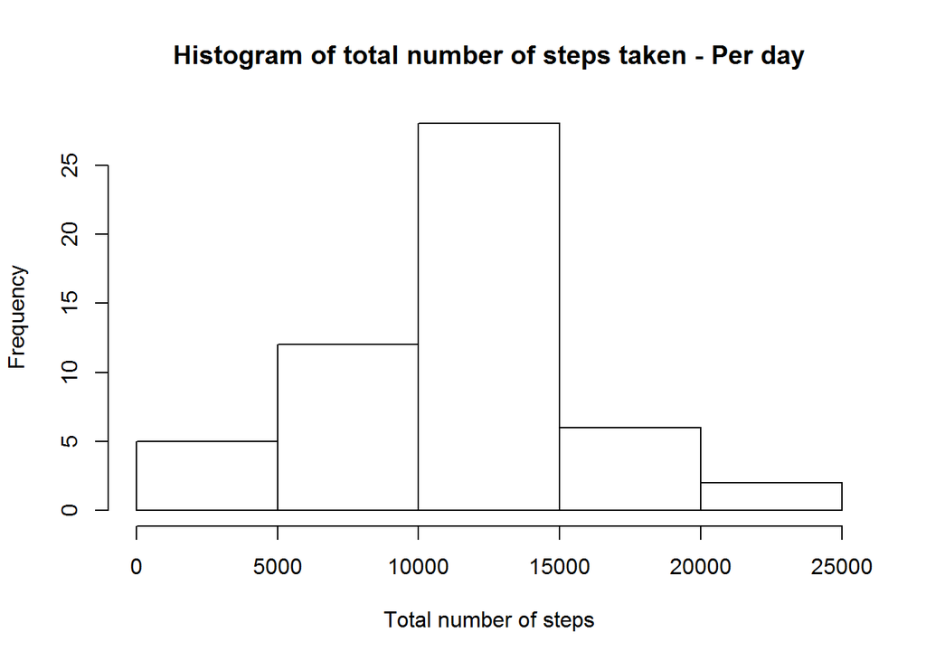

```r
hist(dailysteps$steps, main = "Histogram of total number of steps taken - Per day", xlab="Total number of steps")
```

> 1.2 Calculate and report the mean and median total number of steps taken per day

```r
summary(dailysteps$steps)
```

```
##    Min. 1st Qu.  Median    Mean 3rd Qu.    Max.
##      41    8841   10760   10770   13290   21190
```

```r
mean(dailysteps$steps)
```

```
## [1] 10766.19
```

```r
median(dailysteps$steps)
```

```
## [1] 10765
```

## Questions section 2

> 2.1 What is the average daily activity pattern?

To get average daily activity, we sum the steps per interval for all days. But, Using ‘Function=mean’

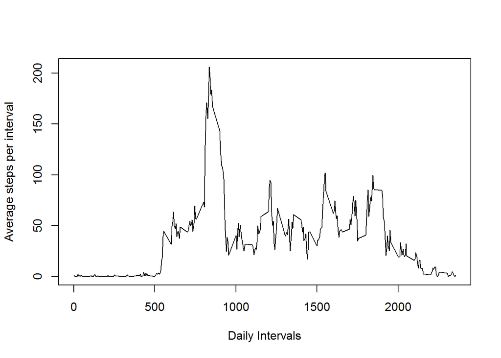

```r
intervalsteps <- aggregate(steps~interval,activity,FUN=mean)

plot(intervalsteps$interval,intervalsteps$steps,type="l",xlab="Daily Intervals",ylab="Average steps per interval")
```

> 2.2 which 5-minute interval, on average across all the days in the dataset, contains the maximum number of steps?

We Calculate the interval using the “max()” function. by Subsisting the data frame to where the ‘steps’ value in data is at its max.

```r
Max.interval<-subset(intervalsteps,steps==max(intervalsteps$steps))
print(Max.interval)
```

```
##     interval    steps
## 104      835 206.1698
```

## Questions section 3

> 3.1 Calculate and report the total number of missing values in the dataset (i.e. the total number of rows with NAs)

```r
sum(is.na(activity$steps))
```

```
## [1] 2304
```

> 3.2 Devise a strategy for filling in all of the missing values in the dataset.

The ‘activity’ data frame before processing

```r
summary(activity)
```

```
##      steps            date              interval
##  Min.   :  0.00   Length:17568       Min.   :   0.0
##  1st Qu.:  0.00   Class :character   1st Qu.: 588.8
##  Median :  0.00   Mode  :character   Median :1177.5
##  Mean   : 37.38                      Mean   :1177.5
##  3rd Qu.: 12.00                      3rd Qu.:1766.2
##  Max.   :806.00                      Max.   :2355.0
##  NA's   :2304
```

```r
head(activity)
```

```
##   steps       date interval
## 1    NA 2012-10-01        0
## 2    NA 2012-10-01        5
## 3    NA 2012-10-01       10
## 4    NA 2012-10-01       15
## 5    NA 2012-10-01       20
## 6    NA 2012-10-01       25
```

Strategy used is to replace occurring NA with the averaged value for that interval across all dates.

This is achieved by going through all rows using a FOR loop. Then, for all rows where there is ‘NA’ for steps, we replace it with the value of steps from ‘intevalsteps’ data calculated before, **making sure that it is for the relevant ‘Time interval’ by finding a matching value of the row 1 value of ‘interval’ and the interval from ‘activity’ of corresponding NA.**

```r
for (i in 1:nrow(activity) )  #Loop 'i' : Go from row 1 to end of Data.frame
  {
        if( is.na(activity[i,1]) )  # Check the value in (Row 'i', Column 1) of activity data frame, TRUE ?
            {
                activity[i,1] <- intervalsteps [
                                       which(activity[i,3]==intervalsteps$interval),2
                                      ]
            # replace the NA, with the value found in
      #intervalsteps[where row 1 value is same as interval of the activty of the correponding NA, col 2 ]
            }
    }
```

> 3.3 Create a new dataset that is equal to the original dataset but with the missing data filled in.

The ‘activity’ data frame after processing

```r
summary(activity)
```

```
##      steps            date              interval
##  Min.   :  0.00   Length:17568       Min.   :   0.0
##  1st Qu.:  0.00   Class :character   1st Qu.: 588.8
##  Median :  0.00   Mode  :character   Median :1177.5
##  Mean   : 37.38                      Mean   :1177.5
##  3rd Qu.: 27.00                      3rd Qu.:1766.2
##  Max.   :806.00                      Max.   :2355.0
```

```r
head(activity)
```

```
##       steps       date interval
## 1 1.7169811 2012-10-01        0
## 2 0.3396226 2012-10-01        5
## 3 0.1320755 2012-10-01       10
## 4 0.1509434 2012-10-01       15
## 5 0.0754717 2012-10-01       20
## 6 2.0943396 2012-10-01       25
```

> 3.4a Make a histogram of the total number of steps taken each day

We calculate the total number of steps by using the aggregate function for ‘steps VS date’, using ‘summation’ function.

```r
dailysteps.no.NA <- aggregate(steps~date,activity,sum)
head(dailysteps.no.NA)
```

```
##         date    steps
## 1 2012-10-01 10766.19
## 2 2012-10-02   126.00
## 3 2012-10-03 11352.00
## 4 2012-10-04 12116.00
## 5 2012-10-05 13294.00
## 6 2012-10-06 15420.00
```

Creating the histogram.

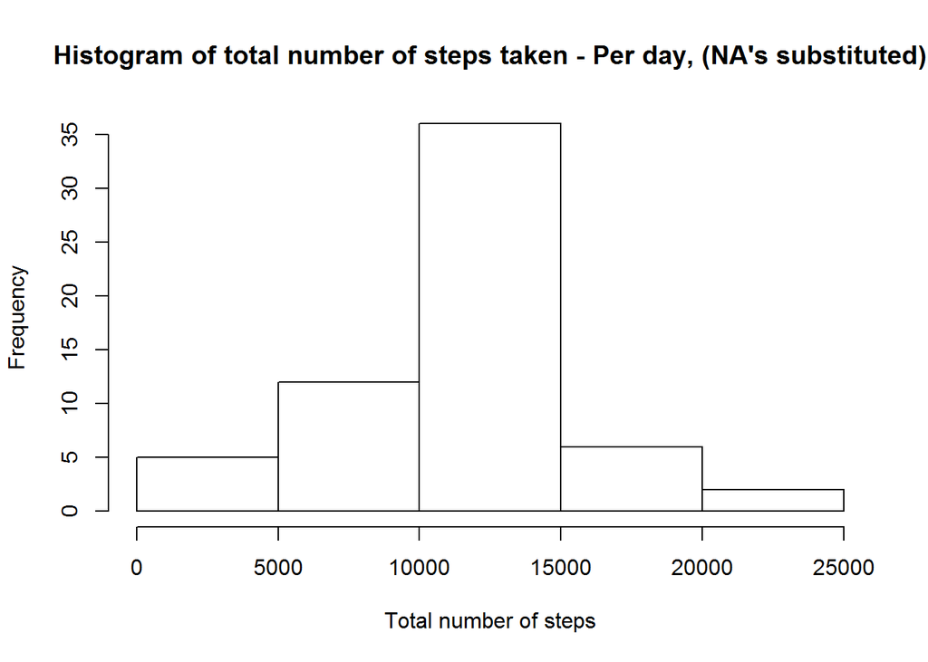

```r
hist(dailysteps.no.NA$steps,main = "Histogram of total number of steps taken - Per day, (NA's substituted)", xlab="Total number of steps")
```

> 3.4b Calculate and report the mean and median total number of steps taken per day.

```r
summary(dailysteps.no.NA$steps)
```

```
##    Min. 1st Qu.  Median    Mean 3rd Qu.    Max.
##      41    9819   10770   10770   12810   21190
```

```r
mean(dailysteps.no.NA$steps)
```

```
## [1] 10766.19
```

```r
median(dailysteps.no.NA$steps)
```

```
## [1] 10766.19
```

> 3.4c Do these values differ from the estimates from the first part of the assignment?

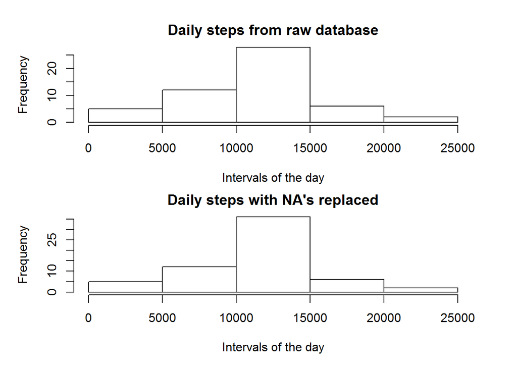

```r
par(mfrow=c(2,1),mar=c(4,4,2,2),oma=c(1,1,1,1))
hist(dailysteps$steps,main="Daily steps from raw database",xlab="Intervals of the day")
hist(dailysteps.no.NA$steps,main="Daily steps with NA's replaced",,xlab="Intervals of the day")
```

```r
summary(dailysteps$steps)
```

```
##    Min. 1st Qu.  Median    Mean 3rd Qu.    Max.
##      41    8841   10760   10770   13290   21190
```

```r
summary(dailysteps.no.NA$steps)
```

```
##    Min. 1st Qu.  Median    Mean 3rd Qu.    Max.
##      41    9819   10770   10770   12810   21190
```

**What is the impact of imputing missing data on the estimates of the total daily number of steps?**

Impact is : Though mean is same, the median is shifted.

## Questions section 4

> 4.1 Are there differences in activity patterns between weekdays and weekends?

we first convert the ‘date’ in activity data frame from ‘Character’ to ‘Date’ data type. Then add a new column called “Day” in data frame which is filled with the relevant day against the date using the Weekdays() function.

```r
activity$date <- as.Date(activity$date, "%Y-%m-%d")
activity$day <- weekdays(activity$date)
str(activity)
```

```
## 'data.frame':    17568 obs. of  4 variables:
##  $ steps   : num  1.717 0.3396 0.1321 0.1509 0.0755 ...
##  $ date    : Date, format: "2012-10-01" "2012-10-01" ...
##  $ interval: int  0 5 10 15 20 25 30 35 40 45 ...
##  $ day     : chr  "Monday" "Monday" "Monday" "Monday" ...
```

Since the day values are “Mon, Tue, Wed..” etc. we write code to separate it into two data frame. ‘Weekdays’ and ‘Weekends’

```r
activity.weekdays <- activity[
                                          c( grep("Monday|Tuesday|Wednesday|Thursday|Friday",activity$day) )
                                #if any row has any of these its weekday
                                    , ]
activity.weekends <- activity[
                                        c( grep("Sunday|Saturday",activity$day) )
                                #if any row has any of these its a weekend
                                    , ]
nrow(activity)
```

```
## [1] 17568
```

```r
str(activity.weekends)
```

```
## 'data.frame':    4608 obs. of  4 variables:
##  $ steps   : num  0 0 0 0 0 0 0 0 0 0 ...
##  $ date    : Date, format: "2012-10-06" "2012-10-06" ...
##  $ interval: int  0 5 10 15 20 25 30 35 40 45 ...
##  $ day     : chr  "Saturday" "Saturday" "Saturday" "Saturday" ...
```

```r
str(activity.weekdays)
```

```
## 'data.frame':    12960 obs. of  4 variables:
##  $ steps   : num  1.717 0.3396 0.1321 0.1509 0.0755 ...
##  $ date    : Date, format: "2012-10-01" "2012-10-01" ...
##  $ interval: int  0 5 10 15 20 25 30 35 40 45 ...
##  $ day     : chr  "Monday" "Monday" "Monday" "Monday" ...
```

*We can check accuracy by adding the row vaules of two subsets and comparing to orginial*

To calculate averages, the data again needs to be averaged against interval to get the trend. So we repeat aggregation on the subsets.

```r
weekday.averages <- aggregate(steps~interval,activity.weekdays,FUN=mean)
weekend.averages <- aggregate(steps~interval,activity.weekends,FUN=mean)

str(weekday.averages)
```

```
## 'data.frame':    288 obs. of  2 variables:
##  $ interval: int  0 5 10 15 20 25 30 35 40 45 ...
##  $ steps   : num  2.251 0.445 0.173 0.198 0.099 ...
```

```r
str(weekend.averages)
```

```
## 'data.frame':    288 obs. of  2 variables:
##  $ interval: int  0 5 10 15 20 25 30 35 40 45 ...
##  $ steps   : num  0.21462 0.04245 0.01651 0.01887 0.00943 ...
```

Plot the data

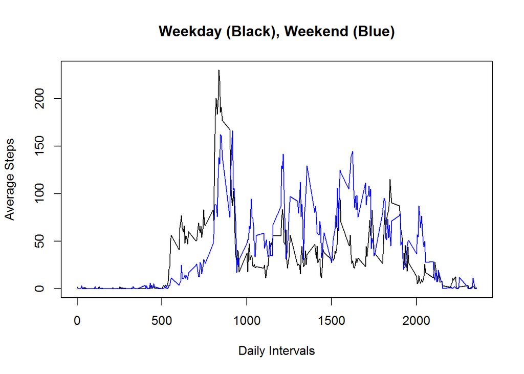

```r
plot(weekday.averages$interval,weekday.averages$steps,type="l",xlab="Daily Intervals",ylab="Average Steps",main="Weekday (Black), Weekend (Blue)")

lines(weekend.averages$interval,weekend.averages$steps,type="l",col="blue")
```

**Result:** We can see that mid day activity during weekend is higher.

*Maybe because the person doesn’t have to sit in the office on weekends !

But, the he highest intensity within a certain interval is still in the weekday.

*Maybe he has to walk stairs up to his office on 200the floor ??